# 13_multiple_transforms

## 13_multiple_transforms

#### Question

1. Some basic [2D-transformation matrices](https://en.wikipedia.org/wiki/Transformation_matrix) are shown:
   - Horizontal stretch by factor $k$ (reflection if $k=-1$).
     $$\begin{bmatrix}k & 0 \\ 0 & 1\end{bmatrix}$$
   - Vertical stretch by factor $k$ (reflection if $k=-1$).
     $$\begin{bmatrix}1 & 0 \\ 0 & k\end{bmatrix}$$
   - Rotation by angle $\theta$ radians.
     $$\begin{bmatrix}\cos(\theta) & -\sin(\theta) \\ \sin(\theta) & \cos(\theta)\end{bmatrix}$$
   - Horizontal shearing by factor $k$.
     $$\begin{bmatrix}1 & k \\ 0 & 1\end{bmatrix}$$
   - Vertical shearing by factor $k$.
     $$\begin{bmatrix}1 & 0 \\ k & 1\end{bmatrix}$$

   When multiple transformations are applied, order matters. If $A$ was the matrix of the first transformation, $B$ was the matrix of the second transformation, $C$ was the matrix of the third transformation, and $X$ was a matrix of column vectors, then the result, $X'$, would be found with the following matrix multiplication:
   $$X' = CBAX$$
   Notice, the order seems backwards; this is standard.

## Problem-specific information

   Begin with the points of a unit square.

   $$X = \begin{bmatrix}0 & 1 & 1 & 0 \\ 0 & 0 & 1 & 1\end{bmatrix}$$

   ```
   X = matrix([[0,1,1,0],[0,0,1,1]])
   polygon(X.transpose(),xmin=-5,xmax=5,ymin=-5,ymax=5,aspect_ratio=1,color="red")
   ```

   Apply the following transformations in the indicated order:
   1. A horizontal stretch by factor 1.3.
   2. A horizontal shear by factor 1.3.
   3. A rotation by angle 1.17.

   Which graph is generated when polygon $X$ is plotted in red and polygon $X'$ is plotted in blue?

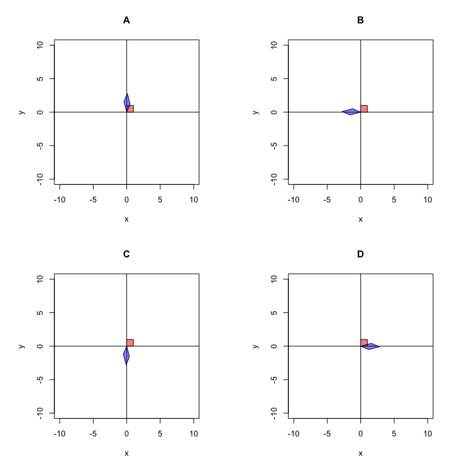

   1. A
   2. B
   3. C
   4. D

#### Question

2. Some basic [2D-transformation matrices](https://en.wikipedia.org/wiki/Transformation_matrix) are shown:
   - Horizontal stretch by factor $k$ (reflection if $k=-1$).
     $$\begin{bmatrix}k & 0 \\ 0 & 1\end{bmatrix}$$
   - Vertical stretch by factor $k$ (reflection if $k=-1$).
     $$\begin{bmatrix}1 & 0 \\ 0 & k\end{bmatrix}$$
   - Rotation by angle $\theta$ radians.
     $$\begin{bmatrix}\cos(\theta) & -\sin(\theta) \\ \sin(\theta) & \cos(\theta)\end{bmatrix}$$
   - Horizontal shearing by factor $k$.
     $$\begin{bmatrix}1 & k \\ 0 & 1\end{bmatrix}$$
   - Vertical shearing by factor $k$.
     $$\begin{bmatrix}1 & 0 \\ k & 1\end{bmatrix}$$

   When multiple transformations are applied, order matters. If $A$ was the matrix of the first transformation, $B$ was the matrix of the second transformation, $C$ was the matrix of the third transformation, and $X$ was a matrix of column vectors, then the result, $X'$, would be found with the following matrix multiplication:
   $$X' = CBAX$$
   Notice, the order seems backwards; this is standard.

## Problem-specific information

   Begin with the points of a unit square.

   $$X = \begin{bmatrix}0 & 1 & 1 & 0 \\ 0 & 0 & 1 & 1\end{bmatrix}$$

   ```
   X = matrix([[0,1,1,0],[0,0,1,1]])
   polygon(X.transpose(),xmin=-5,xmax=5,ymin=-5,ymax=5,aspect_ratio=1,color="red")
   ```

   Apply the following transformations in the indicated order:
   1. A vertical stretch by factor 1.7.
   2. A rotation by angle 5.39.
   3. A horizontal stretch by factor 1.4.

   Which graph is generated when polygon $X$ is plotted in red and polygon $X'$ is plotted in blue?

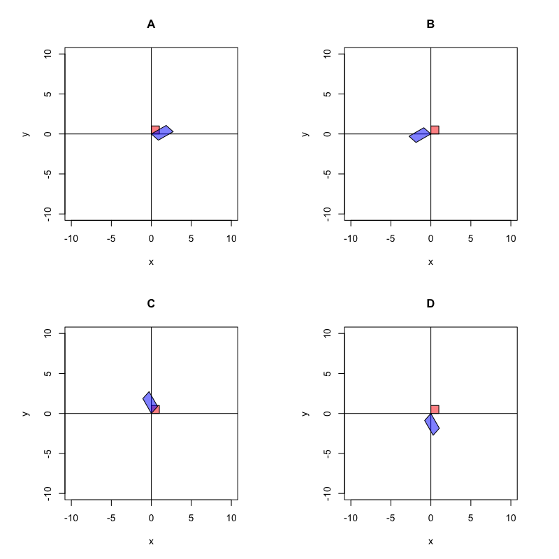

   1. A
   2. B
   3. C
   4. D

#### Question

3. Some basic [2D-transformation matrices](https://en.wikipedia.org/wiki/Transformation_matrix) are shown:
   - Horizontal stretch by factor $k$ (reflection if $k=-1$).
     $$\begin{bmatrix}k & 0 \\ 0 & 1\end{bmatrix}$$
   - Vertical stretch by factor $k$ (reflection if $k=-1$).
     $$\begin{bmatrix}1 & 0 \\ 0 & k\end{bmatrix}$$
   - Rotation by angle $\theta$ radians.
     $$\begin{bmatrix}\cos(\theta) & -\sin(\theta) \\ \sin(\theta) & \cos(\theta)\end{bmatrix}$$
   - Horizontal shearing by factor $k$.
     $$\begin{bmatrix}1 & k \\ 0 & 1\end{bmatrix}$$
   - Vertical shearing by factor $k$.
     $$\begin{bmatrix}1 & 0 \\ k & 1\end{bmatrix}$$

   When multiple transformations are applied, order matters. If $A$ was the matrix of the first transformation, $B$ was the matrix of the second transformation, $C$ was the matrix of the third transformation, and $X$ was a matrix of column vectors, then the result, $X'$, would be found with the following matrix multiplication:
   $$X' = CBAX$$
   Notice, the order seems backwards; this is standard.

## Problem-specific information

   Begin with the points of a unit square.

   $$X = \begin{bmatrix}0 & 1 & 1 & 0 \\ 0 & 0 & 1 & 1\end{bmatrix}$$

   ```
   X = matrix([[0,1,1,0],[0,0,1,1]])
   polygon(X.transpose(),xmin=-5,xmax=5,ymin=-5,ymax=5,aspect_ratio=1,color="red")
   ```

   Apply the following transformations in the indicated order:
   1. A rotation by angle 4.86.
   2. A vertical stretch by factor 1.6.
   3. A horizontal shear by factor 1.4.

   Which graph is generated when polygon $X$ is plotted in red and polygon $X'$ is plotted in blue?

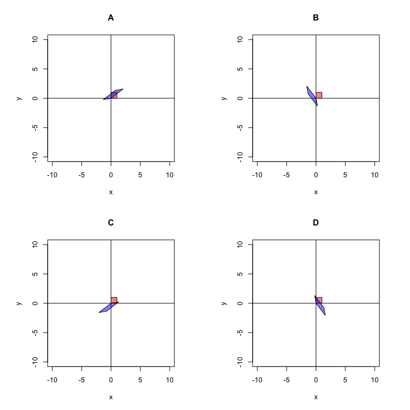

   1. A
   2. B
   3. C
   4. D

#### Question

4. Some basic [2D-transformation matrices](https://en.wikipedia.org/wiki/Transformation_matrix) are shown:
   - Horizontal stretch by factor $k$ (reflection if $k=-1$).
     $$\begin{bmatrix}k & 0 \\ 0 & 1\end{bmatrix}$$
   - Vertical stretch by factor $k$ (reflection if $k=-1$).
     $$\begin{bmatrix}1 & 0 \\ 0 & k\end{bmatrix}$$
   - Rotation by angle $\theta$ radians.
     $$\begin{bmatrix}\cos(\theta) & -\sin(\theta) \\ \sin(\theta) & \cos(\theta)\end{bmatrix}$$
   - Horizontal shearing by factor $k$.
     $$\begin{bmatrix}1 & k \\ 0 & 1\end{bmatrix}$$
   - Vertical shearing by factor $k$.
     $$\begin{bmatrix}1 & 0 \\ k & 1\end{bmatrix}$$

   When multiple transformations are applied, order matters. If $A$ was the matrix of the first transformation, $B$ was the matrix of the second transformation, $C$ was the matrix of the third transformation, and $X$ was a matrix of column vectors, then the result, $X'$, would be found with the following matrix multiplication:
   $$X' = CBAX$$
   Notice, the order seems backwards; this is standard.

## Problem-specific information

   Begin with the points of a unit square.

   $$X = \begin{bmatrix}0 & 1 & 1 & 0 \\ 0 & 0 & 1 & 1\end{bmatrix}$$

   ```
   X = matrix([[0,1,1,0],[0,0,1,1]])
   polygon(X.transpose(),xmin=-5,xmax=5,ymin=-5,ymax=5,aspect_ratio=1,color="red")
   ```

   Apply the following transformations in the indicated order:
   1. A horizontal shear by factor 0.8.
   2. A horizontal stretch by factor 1.9.
   3. A rotation by angle 4.06.

   Which graph is generated when polygon $X$ is plotted in red and polygon $X'$ is plotted in blue?

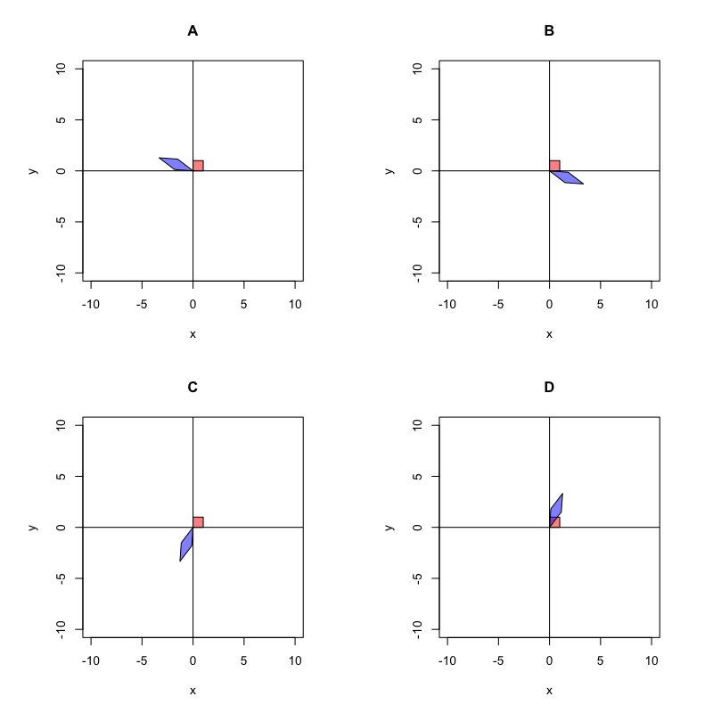

   1. A
   2. B
   3. C
   4. D

#### Question

5. Some basic [2D-transformation matrices](https://en.wikipedia.org/wiki/Transformation_matrix) are shown:
   - Horizontal stretch by factor $k$ (reflection if $k=-1$).
     $$\begin{bmatrix}k & 0 \\ 0 & 1\end{bmatrix}$$
   - Vertical stretch by factor $k$ (reflection if $k=-1$).
     $$\begin{bmatrix}1 & 0 \\ 0 & k\end{bmatrix}$$
   - Rotation by angle $\theta$ radians.
     $$\begin{bmatrix}\cos(\theta) & -\sin(\theta) \\ \sin(\theta) & \cos(\theta)\end{bmatrix}$$
   - Horizontal shearing by factor $k$.
     $$\begin{bmatrix}1 & k \\ 0 & 1\end{bmatrix}$$
   - Vertical shearing by factor $k$.
     $$\begin{bmatrix}1 & 0 \\ k & 1\end{bmatrix}$$

   When multiple transformations are applied, order matters. If $A$ was the matrix of the first transformation, $B$ was the matrix of the second transformation, $C$ was the matrix of the third transformation, and $X$ was a matrix of column vectors, then the result, $X'$, would be found with the following matrix multiplication:
   $$X' = CBAX$$
   Notice, the order seems backwards; this is standard.

## Problem-specific information

   Begin with the points of a unit square.

   $$X = \begin{bmatrix}0 & 1 & 1 & 0 \\ 0 & 0 & 1 & 1\end{bmatrix}$$

   ```
   X = matrix([[0,1,1,0],[0,0,1,1]])
   polygon(X.transpose(),xmin=-5,xmax=5,ymin=-5,ymax=5,aspect_ratio=1,color="red")
   ```

   Apply the following transformations in the indicated order:
   1. A horizontal stretch by factor 2.
   2. A rotation by angle 4.43.
   3. A horizontal shear by factor 1.3.

   Which graph is generated when polygon $X$ is plotted in red and polygon $X'$ is plotted in blue?

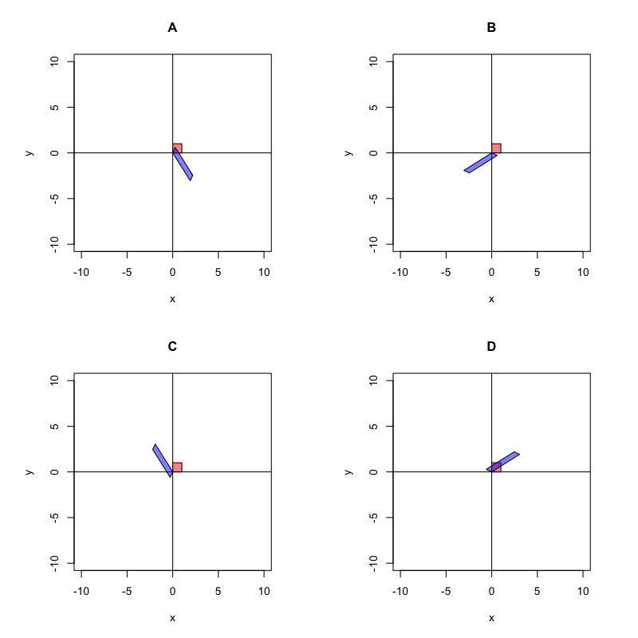

   1. A
   2. B
   3. C
   4. D

#### Question

6. Some basic [2D-transformation matrices](https://en.wikipedia.org/wiki/Transformation_matrix) are shown:
   - Horizontal stretch by factor $k$ (reflection if $k=-1$).
     $$\begin{bmatrix}k & 0 \\ 0 & 1\end{bmatrix}$$
   - Vertical stretch by factor $k$ (reflection if $k=-1$).
     $$\begin{bmatrix}1 & 0 \\ 0 & k\end{bmatrix}$$
   - Rotation by angle $\theta$ radians.
     $$\begin{bmatrix}\cos(\theta) & -\sin(\theta) \\ \sin(\theta) & \cos(\theta)\end{bmatrix}$$
   - Horizontal shearing by factor $k$.
     $$\begin{bmatrix}1 & k \\ 0 & 1\end{bmatrix}$$
   - Vertical shearing by factor $k$.
     $$\begin{bmatrix}1 & 0 \\ k & 1\end{bmatrix}$$

   When multiple transformations are applied, order matters. If $A$ was the matrix of the first transformation, $B$ was the matrix of the second transformation, $C$ was the matrix of the third transformation, and $X$ was a matrix of column vectors, then the result, $X'$, would be found with the following matrix multiplication:
   $$X' = CBAX$$
   Notice, the order seems backwards; this is standard.

## Problem-specific information

   Begin with the points of a unit square.

   $$X = \begin{bmatrix}0 & 1 & 1 & 0 \\ 0 & 0 & 1 & 1\end{bmatrix}$$

   ```
   X = matrix([[0,1,1,0],[0,0,1,1]])
   polygon(X.transpose(),xmin=-5,xmax=5,ymin=-5,ymax=5,aspect_ratio=1,color="red")
   ```

   Apply the following transformations in the indicated order:
   1. A horizontal stretch by factor 1.6.
   2. A rotation by angle 5.03.
   3. A vertical stretch by factor 2.5.

   Which graph is generated when polygon $X$ is plotted in red and polygon $X'$ is plotted in blue?

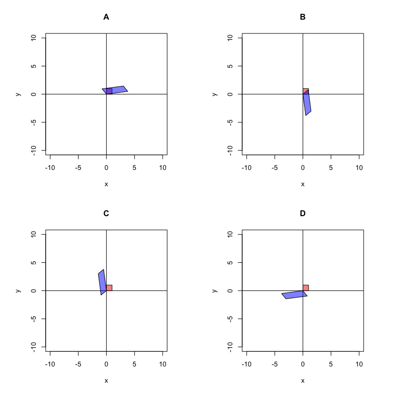

   1. A
   2. B
   3. C
   4. D

#### Question

7. Some basic [2D-transformation matrices](https://en.wikipedia.org/wiki/Transformation_matrix) are shown:
   - Horizontal stretch by factor $k$ (reflection if $k=-1$).
     $$\begin{bmatrix}k & 0 \\ 0 & 1\end{bmatrix}$$
   - Vertical stretch by factor $k$ (reflection if $k=-1$).
     $$\begin{bmatrix}1 & 0 \\ 0 & k\end{bmatrix}$$
   - Rotation by angle $\theta$ radians.
     $$\begin{bmatrix}\cos(\theta) & -\sin(\theta) \\ \sin(\theta) & \cos(\theta)\end{bmatrix}$$
   - Horizontal shearing by factor $k$.
     $$\begin{bmatrix}1 & k \\ 0 & 1\end{bmatrix}$$
   - Vertical shearing by factor $k$.
     $$\begin{bmatrix}1 & 0 \\ k & 1\end{bmatrix}$$

   When multiple transformations are applied, order matters. If $A$ was the matrix of the first transformation, $B$ was the matrix of the second transformation, $C$ was the matrix of the third transformation, and $X$ was a matrix of column vectors, then the result, $X'$, would be found with the following matrix multiplication:
   $$X' = CBAX$$
   Notice, the order seems backwards; this is standard.

## Problem-specific information

   Begin with the points of a unit square.

   $$X = \begin{bmatrix}0 & 1 & 1 & 0 \\ 0 & 0 & 1 & 1\end{bmatrix}$$

   ```
   X = matrix([[0,1,1,0],[0,0,1,1]])
   polygon(X.transpose(),xmin=-5,xmax=5,ymin=-5,ymax=5,aspect_ratio=1,color="red")
   ```

   Apply the following transformations in the indicated order:
   1. A horizontal stretch by factor 1.9.
   2. A vertical shear by factor 1.2.
   3. A rotation by angle 3.11.

   Which graph is generated when polygon $X$ is plotted in red and polygon $X'$ is plotted in blue?

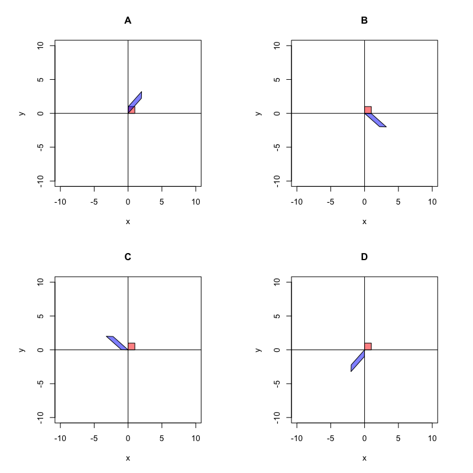

   1. A
   2. B
   3. C
   4. D

#### Question

8. Some basic [2D-transformation matrices](https://en.wikipedia.org/wiki/Transformation_matrix) are shown:
   - Horizontal stretch by factor $k$ (reflection if $k=-1$).
     $$\begin{bmatrix}k & 0 \\ 0 & 1\end{bmatrix}$$
   - Vertical stretch by factor $k$ (reflection if $k=-1$).
     $$\begin{bmatrix}1 & 0 \\ 0 & k\end{bmatrix}$$
   - Rotation by angle $\theta$ radians.
     $$\begin{bmatrix}\cos(\theta) & -\sin(\theta) \\ \sin(\theta) & \cos(\theta)\end{bmatrix}$$
   - Horizontal shearing by factor $k$.
     $$\begin{bmatrix}1 & k \\ 0 & 1\end{bmatrix}$$
   - Vertical shearing by factor $k$.
     $$\begin{bmatrix}1 & 0 \\ k & 1\end{bmatrix}$$

   When multiple transformations are applied, order matters. If $A$ was the matrix of the first transformation, $B$ was the matrix of the second transformation, $C$ was the matrix of the third transformation, and $X$ was a matrix of column vectors, then the result, $X'$, would be found with the following matrix multiplication:
   $$X' = CBAX$$
   Notice, the order seems backwards; this is standard.

## Problem-specific information

   Begin with the points of a unit square.

   $$X = \begin{bmatrix}0 & 1 & 1 & 0 \\ 0 & 0 & 1 & 1\end{bmatrix}$$

   ```
   X = matrix([[0,1,1,0],[0,0,1,1]])
   polygon(X.transpose(),xmin=-5,xmax=5,ymin=-5,ymax=5,aspect_ratio=1,color="red")
   ```

   Apply the following transformations in the indicated order:
   1. A horizontal stretch by factor 2.3.
   2. A vertical stretch by factor 1.6.
   3. A rotation by angle 2.47.

   Which graph is generated when polygon $X$ is plotted in red and polygon $X'$ is plotted in blue?

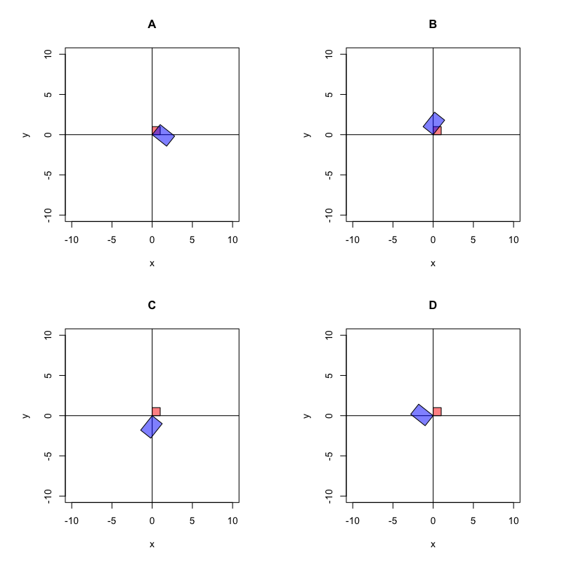

   1. A
   2. B
   3. C
   4. D